# Multilevel Modeling: Within-Person Change

# Visualizing Fixed AND Random Effects

Now we want to add the random effects (intercepts and slopes) into the visual, so that we can see the heterogeneity present in the association between work stressors and relationship dissatisfaction.

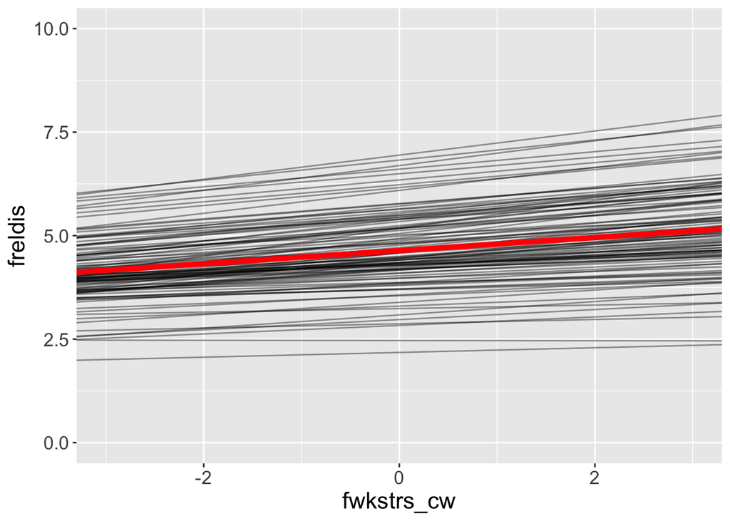

```r
#pull out the random effects
ranefs <- ranef(model_bayes)
#make it into a dataframe
ranefs <- data.frame(as.numeric(rownames(ranefs$id)),ranefs$id)

ggplot(BLch9, aes(fwkstrs_cw, freldis)) +
  #pulling in person specific intercepts and slopes
      geom_abline(ranefs,
                  intercept = ranefs$Estimate.Intercept + 4.639356969,
                  slope = ranefs$Estimate.fwkstrs_cw + 0.158490516,
                  color="black", lwd = .5, alpha = .4) +
  #pulling in fixed effects (average line)
  geom_abline(ranefs, intercept = 4.639356969, slope =  0.158490516,
              color="red", lwd = 1.8, alpha = 1) +
  xlim(-3, 3) + ylim(0, 10) +
  theme(text=element_text(size=16))
```

## Visualize the heterogeneity interval

We can also look at the heterogeneity in an easier/cleaner way by plotting a histogram.

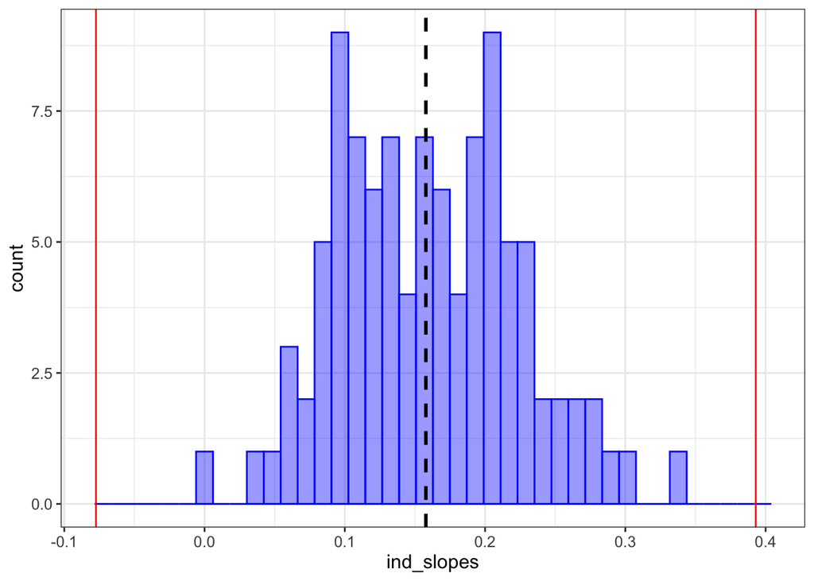

```r
#add the random effects of each person to the fixed effect to get person specific slopes
ranefs$ind_slopes <- ranefs$Estimate.fwkstrs_cw + 0.157782868

ggplot(ranefs, aes(x = ind_slopes)) + geom_histogram(color = "blue", fill = "blue",
                                                              alpha = .4, bins = 40) +
  #fixed effect line
  geom_vline(xintercept = 0.157782868, size = 1, color = "black", linetype="dashed") +
  #create the 95% credibility interval (fixed effect +/- 1.96 * sd of random effect)
  geom_vline(xintercept = 0.157782868 - 1.96*.12, size = .5, color = "red") +
  geom_vline(xintercept = 0.157782868 + 1.96*.12, size = .5, color = "red") +
  theme_bw() + theme(text = element_text(size=12))
```

Note that the population heterogeneity (i.e. what our model tells us and is depicted by the red lines) has a wider interval than our sample heterogeneity (what the actual 100 people’s slopes were from our sample and is depicted by the blue bars). Also note that the fixed effect is not actually where the most participants from our sample lie, but that this is pulled over to the right because of the participants who have higher than average effects.